## IE360 - PROJECT

GROUP 5: Cemre Çadır, Filiz Günal, Miray Matur, Samed Bayer

## INTRODUCTION

E-commerce market size is rapidly increasing in Turkey. According to the report “Turkey E-Commerce, 2019 Market Size”, e-commerce market size in Turkey has increased by 39% and reached 83.1 billion liras.

Keeping service delivery on time is a very important aspect of e-commerce. The reason behind that is e-commerce firms are legally responsible for delivering a service or product within a specified time. It also increases customer satisfaction. Hence, e-commerce firms are collecting various data and they are trying to predict the sales volume by using these.

Trendyol is one of the biggest e-commerce platforms in Turkey. They have more than 200 million annual product sales and over 25 million members. The aim of this project is to predict the next day’s amount of sales for 8 different products that are being sold on Trendyol. For this purpose, the number of sales for each day and eight additional information were given for each product. The information is as follows: average price, number of visits, number of times the product is added to favorites, number of times the product is added to the basket, number of products sold from the same category, number of products sold from the same category brand, number of visits to the category, and the number of Trendyol visits for each day.

One of the most important challenges about this project is resulted from quarantine measures due to pandemic. Since the competition is held during quarantine and the characteristics of the data has significantly changed due to pandemic, data needs to be filtered by date in order to prevent misleading inferences. Another challenge is that each product needs to be analyzed separately because they all have different characteristics.

The NA values in the given data are approximated by interpolation and outliers resulted from big discount days are removed from the data. Naive forecasting, ETS models, automatic ARIMA modeling, linear regression, and dynamic regression are the 5 main models used in this project. The best model is determined for given 8 products and the performance of each model is compared by using MAPE.

## RELATED LITERATURE

Literature research is conducted in order to understand the relevant models and their implementation in a more comprehensive manner.

Comparison Between Regression and Arima Models in Forecasting Traffic Volume: The article investigates the implementation of logistic regression and ARIMA techniques to predict daily traffic volume of Egyptian intercity roads. It also illustrates how to decide which model is best for a given data. In this article, standard deviation error was used.

Forecasting Daily Meteorological Time Series Using Arima And Regression Models: The article examines the application of various models including ARIMA to predict daily air temperature in four European sites. One of the important inferences of this article is that it is very important to use several measures in order to gain reasonable information about the prediction error. Various models and performance measurements can be applied to make a reliable forecast, the crucial part is analyzing data properly and the evaluating the best options.

The links for the articles mentioned above are provided in References section.

## APPROACH

In this project, 5 different models are used to predict the sales amount of the next day. The models that are used can be listed as naive forecasting, ETS models, automatic ARIMA modelling, linear regression, dynamic regression.

Naive forecasting:It is an estimating technique in which last period’s value is used as current period’s forecast. This method does not require any adjustments of data.[1] Therefore this method was used while forecasting some of the regressors in dynamic regression model which will be explained below.

ETS models: In this model, future value is predicted based on exponential smoothing algorithm. Three parameters are used: Error, Trend and Seasonal. Its use focuses on trend and seasonal components. As there were no clear trend and seasonality patterns in the products that were examining, this method was only used in the first submissions of this project, averaged with the automatic ARIMA.

Automatic ARIMA: ARIMA stands for auto-regressive integrated moving average. ARIMA models depend mainly on three variables p, d, and q. The data preparation and parameter tuning might end up being very time consuming therefore auto.arima function is introduced which selects the best ARIMA model according to either AIC,AICC or BIC value. In our project this model is used first to predict the sales count, later it is taken into consideration for prediction of the regressors.We used this method for sales prediction only in the beginning as using auto.arima function alone would neglect the other data that could be used for our estimations.

Linear Regression: Linear regression is a statistical method used to predict future values from the past values. It is one of the most simple and basic methods of forecasting. A linear regression method uses the least squares method to get the optimum trendline so as to minimize the distance between the past values and the trendline. This model fits a best line to the historical performance of the values and extrapolates that into the future according to the best fit line. However, it is not a good model to evaluate the seasonality and nonlinearity effects. Therefore, the simple linear regression is often inappropriate for time-series work, which also explains why we couldn’t make use of this model in our predictions.

Dynamic Regression: Previously information about the time series were only obtained from past observations,however any other information that might be relevant were not included. Unlike linear regression where we assume error terms are white noise, in dynamic regression the error terms are part of an ARIMA process. In our project, we spent our time mostly on the improvement of this model and the main challenges we faced throughout this process were about forecasting the regressors and deciding on which regressors to use. Apart from selecting regressors from the data that we were given, we used a different approach as well while working on this method. As forecasting several values at the same time might be a little problematic, we created a more stationary process where we guess the rate between a highly correlated regressor and sales count.Using this value and the regressor value that is obtained from dynamic regression process, sales count for the next day is predicted.

In order to obtain successful forecast, the data had to be manipulated. First problem in the manipulation process was about which parts of the data should be included. As mentioned in the article on Hurriyet Daily News, the percent growth of e-commerce on FMCG categories increased 57% to 183% in the first 2 months of the pandemic. Therefore, if we have used all the data, we may have got misleading predictions. The figure shows the amount of daily product sales. The effect of pandemic on most of the product sales are clear, especially on personal care products and on household essentials. However, the data starting with March was not enough to train. Therefore, we used the data beginning from the mid-January. By doing so, we removed the outlier values resulting from Black Friday and another special discount day of Trendyol. Secondly, the NA values are approximated with interpolated values.

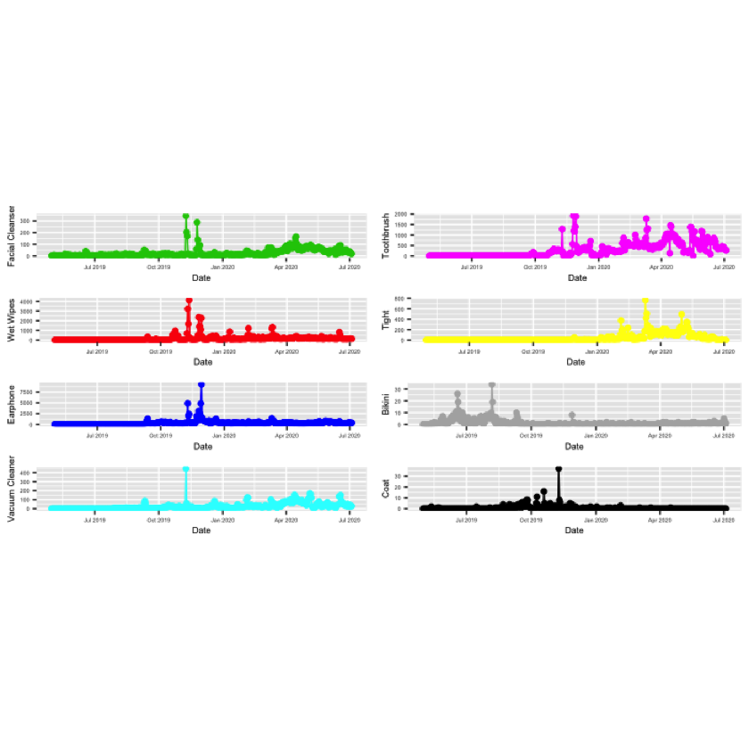

```r
library(png)
library(grid)
image1<-readPNG('/Users/nevalgunal/data-vis-1.png', native=TRUE, info=TRUE)
grid::grid.raster(image1)
```

*Figure 1: The Number of Products Sold in Each Day*

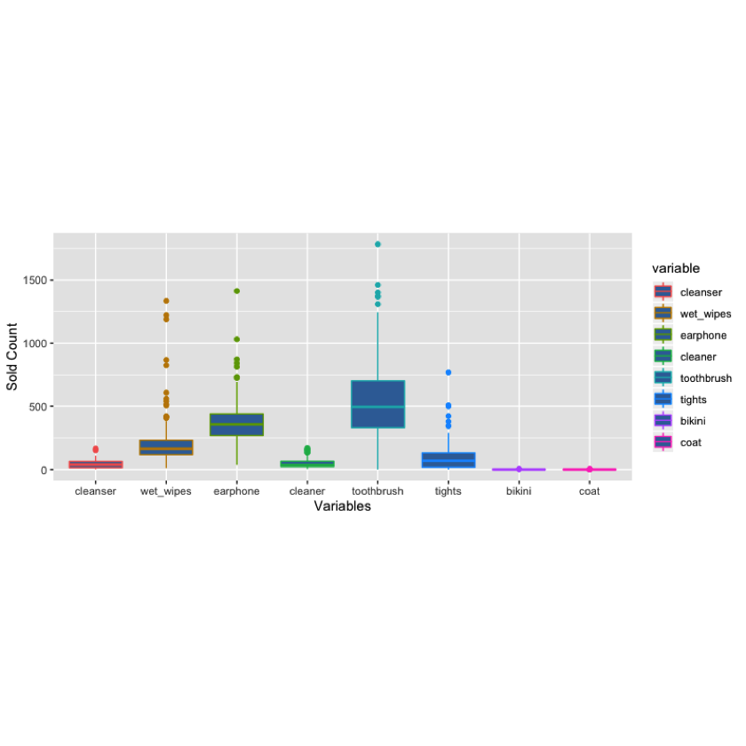

```r
image2<-readPNG('/Users/nevalgunal/data-vis-2.png')
grid::grid.raster(image2)
```

*Figure 2: The Boxplot of Number of Products Sold*

Lastly, to perform the models that mentioned previously, we needed to determine regressors that were related to corresponding product.For this purpose, we analyzed correlations between amount of sales with other characteristics of given products. The figure shows these correlations.

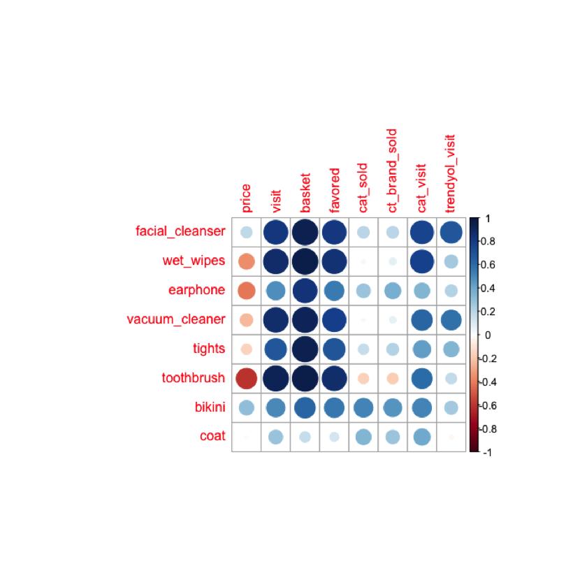

```r
image3<-readPNG('/Users/nevalgunal/data-vis-3.png')
grid::grid.raster(image3)
```

*Figure 3: The Correlations Between Number of Products Sold and Additional Features of the Product*

Time Series Cross Validation (TSCV): Time series cross validation is performed for models mentioned above using custom written code. The test range is determined such that it coincides with the project competition period. The models are compared using MAPE as performance measure.

Accuracy: The actual demands during competition time period are compared against all the different forecasts generated. For that purpose, accuracies of all these methods are calculated by using the mean absolute percent error (MAPE) formula given below. MAPE formula is preferred so as to obtain scale-independent result. The formula is shown below.

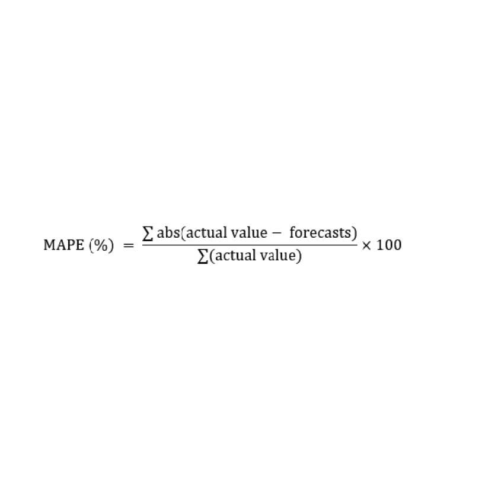

```r
image4<-readPNG('/Users/nevalgunal/Desktop/data-vis-4.png')
grid::grid.raster(image4)
```

## RESULTS

During the submission period, several models were used and compared with each other. These models also differ depending on which product is being examined. For each product, five common and most accurate models are tabulated with their accuracies. Within these models, the models with the most accurate predictions according to MAPE are listed as the best model. In the table below, MAPE values for the second day of predictions are given together with the corresponding model of choice. Different models that were established according to characteristics of the product can be found in the code provided in References.

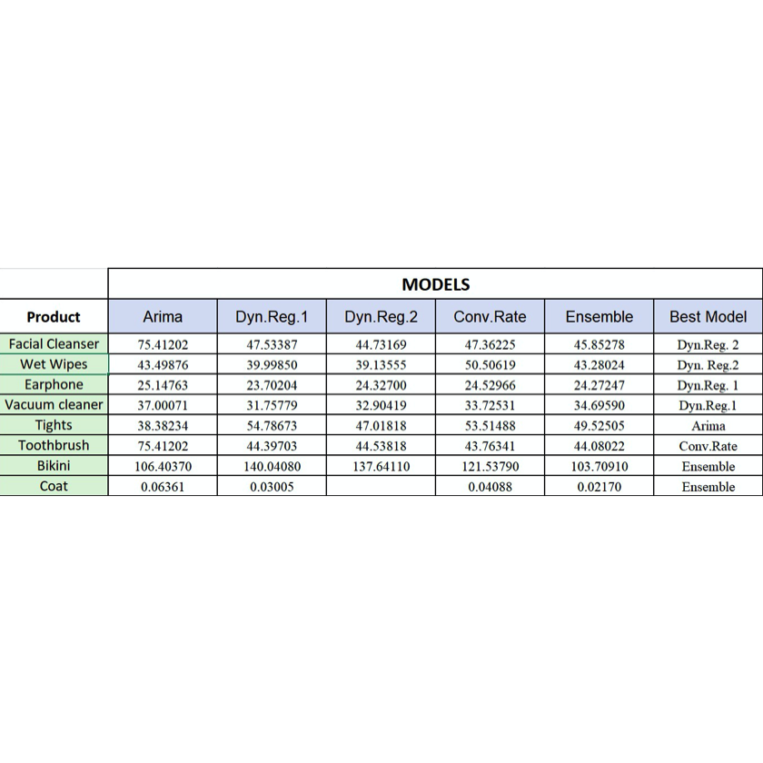

```r
image7<-readPNG('/Users/nevalgunal/Desktop/data-vis-7.png')
grid::grid.raster(image7)
```

*Table 1. MAPE Values of 5 Different Models for Each Product*(MAE is Used for Coat)*

For the competition period, the predictions obtained using the method of choice is provided in the table below together with ground truth, daily weighted mean absolute percentage error (WMAPE), and submission points. This performance measure (WMAPE) is calculated using the formula in the Project Description.

[figure not shown]

```r
image5<-readPNG('/Users/nevalgunal/Desktop/data-vis-6.png')
grid::grid.raster(image5)
```

[output not shown]

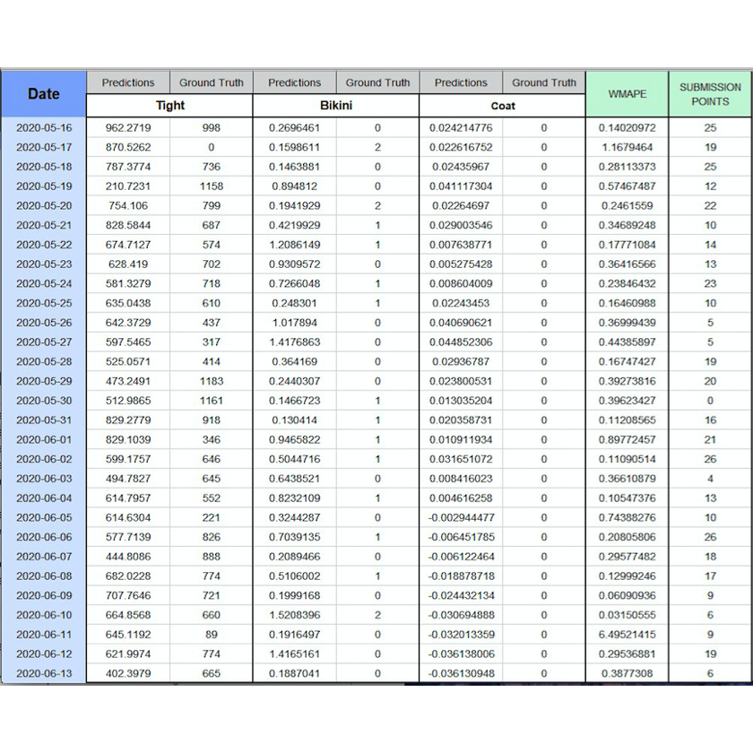

```r
image6<-readPNG('/Users/nevalgunal/Desktop/data-vis-5.png')
grid::grid.raster(image6)
```

*Table 2. Predictions, Ground Truth, WMAPE and Submission Points for Each Day (continued)*

## CONCLUSIONS AND FUTURE WORK

Results are compared in results part. Different models are suitable for predicting data with different characteristics. Because of that, various models are chosen for each product.

To get a better result in the future, there are some assumptions and ideas which might be considered. First one is trying more ensembles. A combination of all the models might be tried and the models might be combined with each other by using varying weights so as to get the best result. Also, external features can be used to train the model more accurately. For example, the effect of the Ramadan month can be added as a feature. Moreover, the effect of the Ramadan Feast can be added too. Before the Ramadan Feast, online shopping becomes more popular among Turkish people. The effect of this popularity cannot be seen in the current dataset. Furthermore, Google Trends gives a perfect information about the society interests. For that reason, keywords searched in Google might be used in the model. If there is an increase in the number of searches of the name of the product, this might be a good indicator of a possible increase of the sales of that product. Just like that, information in other sites might be used as well. For example, platforms like cimri show which website has the best deal. People are using these kind of platforms to decide on the website from which they will buy the product.

Another good indicator of the online shopping is the weather. When the weather is rainy, people stay at home and they tend to buy more online products. The weather forecasting might be used in the model. Also, the negative correlation between coat and bikini might be used to forecast each product. That is, when there is an increase in the coat sales, it is understood that the winter is coming so people tend to not buy bikini anymore. Vice versa is valid as well, when there is a summer, people would buy more bikini. Categorical variables might be used to show the summer time.

## REFERENCES

[1] Deloitte, TUBISAD, Similar Web and Inveon, "Turkey E-Commerce, 2019 Market Size", April 2020 [Online], Available at: https://www2.deloitte.com/tr/tr/pages/technology-media-and-telecommunications/articles/turkiyede-e-ticaret-2019-pazar-buyuklugu.html(Accessed in 6 July 2020)

[2] M. Sabry, H. Abd-El-Latif and N. Badra, "Comparison Between Regression and Arima Models in Forecasting Traffic Volume", 2007 [Online], Available at: https://www.researchgate.net/publication/275152026_Comparison_Between_Regression_and_Arima_Models_in_Forecasting_Traffic_Volume (Accessed in 6 July 2020)

[3] Małgorzata Murat, Iwona Malinowska1, Magdalena Gos, and Jaromir Krzyszczak, 2018 [Online], Available at: http://produkcja.ipan.lublin.pl/uploads/publishing/files/Murat%2032(2).pdf

[4] Yinanc Baris, "COVID-19 proves as catalyzer in e-commerce in Turkey", 01 June 2020 [Online], Available at: https://www.hurriyetdailynews.com/covid-19-proves-as-catalyzer-in-e-commerce-in-turkey-155217 (Accessed in 6 July 2020)

Reference for code is provided [Here](https://htmlpreview.github.io/?https://github.com/BU-IE-360/spring20-gunalfiliz/blob/master/IE360_Project_Code_Group5.html).